# Final Report for Intro to Data Science

# Loading Prerequisites

```r
library(tidyverse)
```

```r
Esports <- read_csv("https://raw.githubusercontent.com/Th3L0stN3rd/Final-Project-FPU/master/data/GeneralEsportData.csv?token=AKWHJYZYIIYRRATTGUBRSDTBCCZR4")
```

```r
Esports
```

| Game | ReleaseDate | Genre | TotalEarnings | OnlineEarnings | TotalPlayers | TotalTournaments |
| --- | --- | --- | --- | --- | --- | --- |
| Age of Empires | 1997 | Strategy | 190262.81 | 156839.89 | 255 | 96 |
| Age of Empires II | 1999 | Strategy | 1949008.74 | 619582.87 | 1357 | 989 |
| Age of Empires III | 2005 | Strategy | 68613.85 | 41500.00 | 108 | 77 |
| Age of Empires Online | 2011 | Strategy | 4078.56 | 0.00 | 19 | 12 |
| Age of Mythology | 2002 | Strategy | 52360.00 | 52000.00 | 22 | 6 |
| Among Us | 2018 | Strategy | 86000.00 | 0.00 | 14 | 8 |
| Auto Chess | 2019 | Strategy | 1136420.28 | 1035522.28 | 112 | 8 |
| Brawl Stars | 2018 | Strategy | 1557950.00 | 336250.00 | 212 | 30 |
| Chess.com | 2007 | Strategy | 1340988.94 | 0.00 | 679 | 234 |
| chess24 | 2014 | Strategy | 2205625.43 | 0.00 | 74 | 16 |

[output cut: 525 more lines]

## Let’s Get to The EDA

First, we can find the most total earnings of all `Games`, `Genres` and `Release Dates:`

```r
Esports %>%
  select(Game, TotalEarnings, Genre) %>%
  arrange(desc(TotalEarnings))
```

| Game | TotalEarnings | Genre |
| --- | --- | --- |
| Dota 2 | 234795551.17 | Multiplayer Online Battle Arena |
| Counter-Strike: Global Offensive | 117125739.01 | First-Person Shooter |
| Fortnite | 106481419.15 | Battle Royale |
| League of Legends | 84189144.84 | Multiplayer Online Battle Arena |
| StarCraft II | 35209629.78 | Strategy |
| PLAYERUNKNOWN\x92S BATTLEGROUNDS | 33572921.92 | Battle Royale |
| Overwatch | 27225317.28 | First-Person Shooter |
| Arena of Valor | 26561485.80 | Multiplayer Online Battle Arena |
| Hearthstone | 25244153.47 | Collectible Card Game |
| Heroes of the Storm | 18193482.65 | Multiplayer Online Battle Arena |

[output cut: 525 more lines]

Let’s take a look at Dota2’s Genre as it is the top total earning game:

```r
Esports %>%
  select(Game, TotalEarnings, Genre) %>%
  filter(Genre == "Multiplayer Online Battle Arena") %>%
  arrange(desc(TotalEarnings))
```

| Game | TotalEarnings | Genre |
| --- | --- | --- |
| Dota 2 | 234795551.17 | Multiplayer Online Battle Arena |
| League of Legends | 84189144.84 | Multiplayer Online Battle Arena |
| Arena of Valor | 26561485.80 | Multiplayer Online Battle Arena |
| Heroes of the Storm | 18193482.65 | Multiplayer Online Battle Arena |
| SMITE | 9250112.75 | Multiplayer Online Battle Arena |
| Heroes of Newerth | 2918706.56 | Multiplayer Online Battle Arena |
| Defense of the Ancients | 857420.65 | Multiplayer Online Battle Arena |
| Vainglory | 797421.19 | Multiplayer Online Battle Arena |
| Minecraft | 429539.15 | Multiplayer Online Battle Arena |
| Hyper Scape | 299000.00 | Multiplayer Online Battle Arena |

[output cut: 13 more lines]

We can see that Dota2 takes the cake in terms of earnings by a long shot

```r
round(234795551.17 - 84189144.8)
```

```
[1] 150606406
```

We can see that Dota2 has `~$150m` more total earnings than the next competing Game in the same Genre

```r
Esports %>%
  select(Game, TotalEarnings, Genre) %>%
  arrange(desc(TotalEarnings))
```

| Game | TotalEarnings | Genre |
| --- | --- | --- |
| Dota 2 | 234795551.17 | Multiplayer Online Battle Arena |
| Counter-Strike: Global Offensive | 117125739.01 | First-Person Shooter |
| Fortnite | 106481419.15 | Battle Royale |
| League of Legends | 84189144.84 | Multiplayer Online Battle Arena |
| StarCraft II | 35209629.78 | Strategy |
| PLAYERUNKNOWN\x92S BATTLEGROUNDS | 33572921.92 | Battle Royale |
| Overwatch | 27225317.28 | First-Person Shooter |
| Arena of Valor | 26561485.80 | Multiplayer Online Battle Arena |
| Hearthstone | 25244153.47 | Collectible Card Game |
| Heroes of the Storm | 18193482.65 | Multiplayer Online Battle Arena |

[output cut: 525 more lines]

```r
round(234795551.17 - 117125739.01)
```

```
[1] 117669812
```

We can also see that Dota2 has `~$117m` more total earnings than the next competing Game as a whole. However we will eventually look into how many actual tournaments were played in relation to its total earnings.

[figure not shown]

For our personal interests, let’s look at FPS games.

```r
Esports %>%
  select(Game, TotalEarnings, Genre) %>%
  filter(Genre == "First-Person Shooter") %>%
  arrange(desc(TotalEarnings))
```

| Game | TotalEarnings | Genre |
| --- | --- | --- |
| Counter-Strike: Global Offensive | 117125739.01 | First-Person Shooter |
| Overwatch | 27225317.28 | First-Person Shooter |
| Rainbow Six Siege | 17378920.14 | First-Person Shooter |
| Counter-Strike | 13553955.46 | First-Person Shooter |
| Call of Duty: Modern Warfare | 7500784.50 | First-Person Shooter |
| Halo 5: Guardians | 7071480.97 | First-Person Shooter |
| Call of Duty: Black Ops 4 | 6731938.95 | First-Person Shooter |
| CrossFire | 6609445.02 | First-Person Shooter |
| Call of Duty: Warzone | 5628196.86 | First-Person Shooter |
| VALORANT | 4982645.20 | First-Person Shooter |

[output cut: 97 more lines]

With no surprise on our end, we see `CS:GO` as the top dog in earnings out of all `First-Person Shooter` games.

[figure not shown]

Now let’s look at the least total earned Games.

```r
Esports %>%
  select(Game, TotalEarnings, Genre) %>%
  arrange(TotalEarnings)
```

| Game | TotalEarnings | Genre |
| --- | --- | --- |
| Endgods | 0.00 | Strategy |
| Heroes of Might and Magic III | 0.00 | Strategy |
| Iron Harvest | 0.00 | Strategy |
| Men of War: Assault Squad 2 | 0.00 | Strategy |
| Warhammer 40,000: Dawn of War II | 0.00 | Strategy |
| Battlefield 1 | 0.00 | First-Person Shooter |
| Battlefield 5 | 0.00 | First-Person Shooter |
| Echo Arena | 0.00 | First-Person Shooter |
| Halo: Infinite | 0.00 | First-Person Shooter |
| Ironsight | 0.00 | First-Person Shooter |

[output cut: 525 more lines]

Just from this output, we can see some discrepancies with earnings such as `Halo: Infinite`. It’s evident that this game has not been released yet as of 08-07-2021. Let us look at the total tournaments for said game.

```r
Esports %>%
  select(Game, TotalTournaments, Genre) %>%
  filter(Game == "Halo: Infinite")  %>%
  arrange(TotalTournaments)
```

| Game | TotalTournaments | Genre |
| --- | --- | --- |
| Halo: Infinite | 0 | First-Person Shooter |

Coming from this output, this specific dataset has `Games` with **no** `Total Tournaments`, so lets clean this up to get rid of potential games that have not been released yet, such as `Halo: Infinite`.

```r
Esports <- Esports %>%
  filter(TotalTournaments > 0)

Esports %>%
  select(Game, TotalEarnings, TotalTournaments, Genre) %>%
  arrange(TotalTournaments)
```

| Game | TotalEarnings | TotalTournaments | Genre |
| --- | --- | --- | --- |
| ComPet | 2000.00 | 1 | Strategy |
| Identity V | 31911.10 | 1 | Strategy |
| Internet Chess Club | 10000.00 | 1 | Strategy |
| Rise of Nations: Rise of Legends | 69600.00 | 1 | Strategy |
| Star Wars: Squadrons | 800.00 | 1 | Strategy |
| Super Mario Party | 220.00 | 1 | Strategy |
| Supreme Commander | 4901.26 | 1 | Strategy |
| Supreme Commander: Forged Alliance | 1290.01 | 1 | Strategy |
| TEPPEN | 456721.47 | 1 | Strategy |
| Aliens versus Predator 2 | 40000.00 | 1 | First-Person Shooter |

[output cut: 491 more lines]

Now that we know what games have the most total earnings, let us look at the relation between `Total Earnings` and `Total Tournaments`.

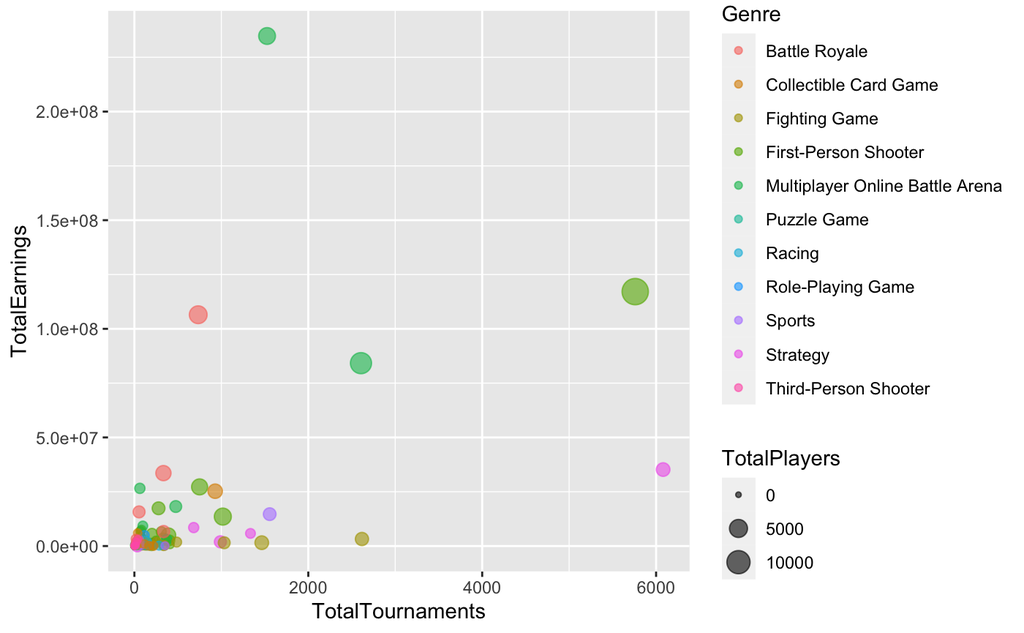

```r
ggplot(Esports) +
  geom_point(aes(x = TotalTournaments, y = TotalEarnings, color = Genre, size = TotalPlayers),
             alpha = 0.6)
```

We first can see a clump of Genre’s where there isn’t much ‘activity’ in terms of tournaments or earnings. This could indicate unpopularity within the gaming community for these Genre’s. Interestingly, we have one point where a `Strategy` game has had `~6000` tournaments but made much less than the big titles such as `CS:GO` or `Dota2`. Let’s look at which game this could be:

```r
Esports %>%
  filter(Genre == "Strategy", TotalTournaments >= 6000)
```

| Game | ReleaseDate | Genre | TotalEarnings | OnlineEarnings | TotalPlayers | TotalTournaments |
| --- | --- | --- | --- | --- | --- | --- |
| StarCraft II | 2010 | Strategy | 35209630 | 29224875 | 2098 | 6081 |

[figure not shown]

Now out of this dataset, let’s determine the most popular Genres:

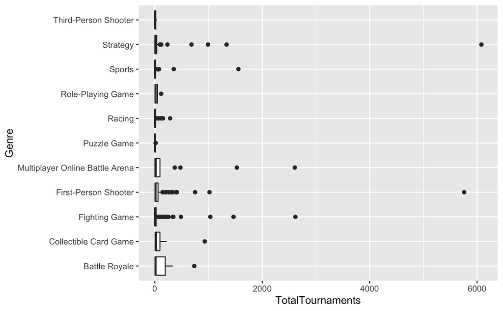

```r
ggplot(Esports) +
  geom_boxplot(aes(x = TotalTournaments, y = Genre))
```

```r
NA
```

Looking at the vast outliers in these Game Genre’s, we can see that `First-Person Shooter` and `Strategy` genre’s are leading in popularity as we have deduced from earlier (**SOLEY BASED ON TOTAL TOURNAMENTS**). However we do see that `Fighting Game` and `Multiplayer Online Battle Arena` do make up the 3rd and 4th most played game `Genre`’s respectively.